# ANN_Project_Seq_to_Seq_GRU

Loading the Libraries & Data

```python
import warnings
warnings.filterwarnings('ignore')

import numpy as np
import pandas as pd
import matplotlib.pyplot as plt
from scipy import stats
import seaborn as sb
from sklearn.model_selection import train_test_split
from sklearn.preprocessing import MinMaxScaler
import seaborn as sb

import torch
import torch.nn as nn
import torch.utils.data as td

# reading the data
jena_df = pd.read_csv("jena_climate_2009_2016.csv")

jena_df = jena_df.rename(columns={"Date Time": "DateTime", "p (mbar)": "Pressure", "T (degC)": "TempCelsius", "Tpot (K)": "TempKelvin", "Tdew (degC)": "TempDewCelsius",
                        "rh (%)": "RelativeHumidity", "VPmax (mbar)": "SatVapourPress", "VPact (mbar)": "VapourPressure", "VPdef (mbar)": "VapPressDeficit",
                        "sh (g/kg)": "SpecificHumidity", "H2OC (mmol/mol)": "WaterVapConc", "rho (g/m**3)": "AirDensity", "wv (m/s)": "WindSpeed",
                        "max. wv (m/s)": "MaxWindSpeed", "wd (deg)": "WindDirDegrees"})
```

**Data Preprocessing**

All these steps are explained in the data cleaning sheet and combined here in one cell for fast processing of the data.

```python
#taking only the hourly values
jena_df = jena_df[5::6]

#removing incorrect values
jena_df['WindSpeed'].replace(-9999, 0, inplace = True)
jena_df['MaxWindSpeed'].replace(-9999, 0, inplace = True)

#treating outliers
def out_treat(var):
    Q1 = np.quantile(var.dropna(), 0.25)
    Q3 = np.quantile(var.dropna(), 0.75)
    IQR = Q3-Q1
    LC = Q1 - (3 * IQR)
    UC = Q3 + (3 * IQR)
    var[var > UC] = UC
    var[var < LC] = LC
    return (var)
jena_df = jena_df[~jena_df.index.duplicated()]

jena_df.Pressure = out_treat(jena_df.Pressure)
jena_df.SatVapourPress = out_treat(jena_df.SatVapourPress)
jena_df.VapPressDeficit = out_treat(jena_df.VapPressDeficit)
jena_df.AirDensity = out_treat(jena_df.AirDensity)

#deriving the wind vector components
wv = jena_df.pop('WindSpeed')
max_wv = jena_df.pop('MaxWindSpeed')
# Convert to radians.
wd_rad = jena_df.pop('WindDirDegrees')*np.pi / 180
# Calculate the wind x and y components.
jena_df['Wx'] = wv*np.cos(wd_rad)
jena_df['Wy'] = wv*np.sin(wd_rad)
# Calculate the max wind x and y components.
jena_df['max Wx'] = max_wv*np.cos(wd_rad)
jena_df['max Wy'] = max_wv*np.sin(wd_rad)

#drop variables that have redundant data (multicollinearity)
jena_df.drop(['TempCelsius'],axis=1,inplace=True)
jena_df.drop(['VapourPressure'],axis=1,inplace=True)
jena_df.drop(['WaterVapConc'],axis=1,inplace=True)

#setting datetime as the index
jena_df.set_index('DateTime',inplace=True, drop=True)

#Seperating the independent and dependent data
data = jena_df
X = data.drop(columns=["TempKelvin"],axis=1)
y = data["TempKelvin"]

#Splitting the data for training and testing
x_train, x_test, y_train, y_test = train_test_split(X.values,y.values, test_size=0.2, shuffle=False)

#Scaling - Fit and Transform TRAIN data
min_max_scaler_x = MinMaxScaler()
x_train_sc = min_max_scaler_x.fit_transform(x_train)
x_test_sc = min_max_scaler_x.transform(x_test)

#Scaling - Fit and Transform TEST data
min_max_scaler_y = MinMaxScaler()    #we will use this scaler later to inverse transform predicted values
y_train_sc = min_max_scaler_y.fit_transform(y_train.reshape(-1,1))
y_test_sc = min_max_scaler_y.transform(y_test.reshape(-1,1))

#Converting back to Pandas dataframe
x_train = pd.DataFrame(x_train_sc, columns = X.columns)
x_test = pd.DataFrame(x_test_sc, columns = X.columns)
y_train = pd.DataFrame(y_train_sc, columns = ["TempKelvin"])
y_test = pd.DataFrame(y_test_sc, columns = ["TempKelvin"])

#merging the two datasets for both training and testing data
last_col = y_train.pop("TempKelvin")
x_train.insert(x_train.shape[1], "TempKelvin", last_col)
last_col = y_test.pop("TempKelvin")
x_test.insert(x_test.shape[1], "TempKelvin", last_col)

#concatenating train and test data
data = x_train.append(x_test)
```

**Creating Sequences & Transforming to tensors**

Step by Step Explanation:

1] Creating sequences of 168 lags (1 week of historical data)taken for all the data.

2] Splitting the data into train and test section as decided before.

3] Slicing the numpy arrays from both train and test data to create sequences train_x, train_y, test_x and test_y. (Keeping the mind here our train_y and test_y will be sequences of temperature over the next 24 hours.)

4] Transforming the numpy arrays into PyTorch tensors.

5] Joining input sequences tensors with output sequences tensors.

6] Defining batch size for train and test data and creating data loader files for both training and testing.

```python
def split_data(inputDF, lookback, multiout):
    data_raw = inputDF.to_numpy() # convert to numpy array
    data = []

    # create all possible sequences of length seq_len
    for index in range(len(data_raw) - lookback):
        data.append(data_raw[index: index + lookback])

    data = np.array(data);
    test_set_size = int(np.round(0.2*data.shape[0]));
    train_set_size = data.shape[0] - (test_set_size);

    x_train = data[:train_set_size, :, :]
    y_train = data[lookback:train_set_size+lookback, :multiout, -1]

    x_test = data[train_set_size:-lookback, :, :]
    y_test = data[train_set_size+lookback:, :multiout, -1]

    return [x_train, y_train, x_test, y_test]


lookback = 168 # choose sequence length
multiout = 24 #series of temperatures that we will predict
x_train, y_train, x_test, y_test = split_data(data, lookback, multiout)

# converting numpy arrays to tensors
x_train = torch.from_numpy(x_train).type(torch.Tensor)
x_test = torch.from_numpy(x_test).type(torch.Tensor)
y_train = torch.from_numpy(y_train).type(torch.Tensor)
y_test = torch.from_numpy(y_test).type(torch.Tensor)

y_train = y_train.view(len(y_train), multiout)
y_test = y_test.view(len(y_test), multiout)

# creating dataloader objects
train_tensor = torch.utils.data.TensorDataset(x_train, y_train)
train_loader = torch.utils.data.DataLoader(dataset = train_tensor, batch_size = np.math.ceil(len(x_train)/10), shuffle = False)

test_tensor = torch.utils.data.TensorDataset(x_test, y_test)
test_loader = torch.utils.data.DataLoader(dataset = test_tensor, batch_size = len(x_test),shuffle = False)
```

Checking if GPU available, then using it!

```python
device = torch.device('cuda' if torch.cuda.is_available() else 'cpu')
print("SELECTED DEVICE: ", device)
torch.cuda.empty_cache()
host = torch.device('cpu')
print("HOST DEVICE: ", host)
```

```
SELECTED DEVICE:  cuda
HOST DEVICE:  cpu
```

# GRU

Network Structure

```python
class GRU(nn.Module):
    def __init__(self, input_dim, hidden_dim, num_layers, output_dim):
        super(GRU, self).__init__()
        self.hidden_dim = hidden_dim
        self.num_layers = num_layers

        self.gru = nn.GRU(input_dim, hidden_dim, num_layers, batch_first=True)
        self.fc = nn.Linear(hidden_dim, output_dim)
    def forward(self, x):
        h0 = torch.zeros(self.num_layers, x.size(0), self.hidden_dim).requires_grad_().to(device)
        out, (hn) = self.gru(x, (h0.detach()))
        out = self.fc(out[:, -1, :])
        return out
```

**Defining the Model**

```python
input_dim = 12
hidden_dim = 16
output_dim = multiout
num_layers = 2
num_epochs = 60

model = GRU(input_dim=input_dim, hidden_dim=hidden_dim, num_layers = num_layers, output_dim=output_dim)
model.to(device)
criterion = torch.nn.MSELoss(reduction='mean')
optimiser = torch.optim.Adam(model.parameters(), lr=0.01)
```

Running Model over Epochs

```python
#defining a function for test data
def validation(model):
    with torch.no_grad():
        for input, target in test_loader:
            y_test_pred = model(input.to(device))
            test_loss = criterion(y_test_pred, target.to(device))
    return test_loss.item(), y_test_pred

#training over the number of epochs
import time #to measure the time taken by model to run
training_losses = np.zeros(num_epochs)
testing_losses = np.zeros(num_epochs)
start_time = time.time()
for t in range(num_epochs):
    for input, target in train_loader:
        y_train_pred = model(input.to(device)) #predicted values of train data
        train_loss = criterion(y_train_pred, target.to(device)) #calculate train loss

        optimiser.zero_grad() #making the gradients zero
        train_loss.backward() #backpropogating through the network by changing weights
        optimiser.step()

    training_losses[t] = train_loss.item()
    testing_losses[t] = validation(model)[0]

    print("Epoch ", t, "Train MSE: ", train_loss.item(), "Test MSE: ", validation(model)[0])


training_time = time.time()-start_time
print("Training time: {}".format(training_time))
```

```
Epoch  0 Train MSE:  0.03053892031311989 Test MSE:  0.03149866685271263
Epoch  1 Train MSE:  0.016666512936353683 Test MSE:  0.019942721351981163
Epoch  2 Train MSE:  0.008031048811972141 Test MSE:  0.009446336887776852
Epoch  3 Train MSE:  0.005564483813941479 Test MSE:  0.006942726671695709
Epoch  4 Train MSE:  0.00493979174643755 Test MSE:  0.005772267933934927
Epoch  5 Train MSE:  0.0045083449222147465 Test MSE:  0.004850287456065416
Epoch  6 Train MSE:  0.003999646287411451 Test MSE:  0.004586430266499519
Epoch  7 Train MSE:  0.004117451608181 Test MSE:  0.004405962768942118
Epoch  8 Train MSE:  0.0038627043832093477 Test MSE:  0.004303398076444864
Epoch  9 Train MSE:  0.003787847701460123 Test MSE:  0.00425221910700202
Epoch  10 Train MSE:  0.003703432623296976 Test MSE:  0.004214348737150431
Epoch  11 Train MSE:  0.0036617042496800423 Test MSE:  0.0041927071288228035
Epoch  12 Train MSE:  0.0036160380113869905 Test MSE:  0.004171650391072035
Epoch  13 Train MSE:  0.003576883114874363 Test MSE:  0.004151106346398592
Epoch  14 Train MSE:  0.0035441359505057335 Test MSE:  0.0041219149716198444
Epoch  15 Train MSE:  0.003523551393300295 Test MSE:  0.004079140722751617
Epoch  16 Train MSE:  0.0035092029720544815 Test MSE:  0.004027397371828556
Epoch  17 Train MSE:  0.0034892114344984293 Test MSE:  0.003982785623520613
Epoch  18 Train MSE:  0.003458410734310746 Test MSE:  0.003951344173401594
Epoch  19 Train MSE:  0.003429171396419406 Test MSE:  0.003916578833013773
Epoch  20 Train MSE:  0.0034033823758363724 Test MSE:  0.0038735540583729744
Epoch  21 Train MSE:  0.003377386601641774 Test MSE:  0.0038280547596514225
Epoch  22 Train MSE:  0.003347179386764765 Test MSE:  0.0037809896748512983
Epoch  23 Train MSE:  0.003316242480650544 Test MSE:  0.0037296481896191835
Epoch  24 Train MSE:  0.003286088816821575 Test MSE:  0.0036757385823875666
Epoch  25 Train MSE:  0.0032502692192792892 Test MSE:  0.003618222661316395
Epoch  26 Train MSE:  0.003217977937310934 Test MSE:  0.0035579288378357887
Epoch  27 Train MSE:  0.003180338302627206 Test MSE:  0.0034951171837747097
Epoch  28 Train MSE:  0.003149680094793439 Test MSE:  0.0034302566200494766
Epoch  29 Train MSE:  0.0031177059281617403 Test MSE:  0.003362401621416211
Epoch  30 Train MSE:  0.003096161177381873 Test MSE:  0.0032929047010838985
Epoch  31 Train MSE:  0.0030788970179855824 Test MSE:  0.0032245509792119265
Epoch  32 Train MSE:  0.0030591159593313932 Test MSE:  0.0031600389629602432
Epoch  33 Train MSE:  0.0030220202170312405 Test MSE:  0.00309764570556581
Epoch  34 Train MSE:  0.002969276625663042 Test MSE:  0.0030313078314065933
Epoch  35 Train MSE:  0.0029244888573884964 Test MSE:  0.0029626768082380295
Epoch  36 Train MSE:  0.0028986854013055563 Test MSE:  0.002901824889704585
Epoch  37 Train MSE:  0.002886296948418021 Test MSE:  0.0028506177477538586
Epoch  38 Train MSE:  0.0028544652741402388 Test MSE:  0.0028042574413120747
Epoch  39 Train MSE:  0.002792645711451769 Test MSE:  0.0027586580254137516
Epoch  40 Train MSE:  0.002740940311923623 Test MSE:  0.002714640460908413
Epoch  41 Train MSE:  0.0027107815258204937 Test MSE:  0.0026783328503370285
Epoch  42 Train MSE:  0.002692061010748148 Test MSE:  0.002642478095367551
Epoch  43 Train MSE:  0.002668739063665271 Test MSE:  0.002609426621347666
Epoch  44 Train MSE:  0.002625706372782588 Test MSE:  0.0025806103367358446
Epoch  45 Train MSE:  0.002579691354185343 Test MSE:  0.0025483397766947746
Epoch  46 Train MSE:  0.002547141397371888 Test MSE:  0.002521093236282468
Epoch  47 Train MSE:  0.002523165661841631 Test MSE:  0.002502331044524908
Epoch  48 Train MSE:  0.0025082631036639214 Test MSE:  0.0024881702847778797
Epoch  49 Train MSE:  0.0024954413529485464 Test MSE:  0.002473169472068548
Epoch  50 Train MSE:  0.0024717217311263084 Test MSE:  0.002453157212585211
Epoch  51 Train MSE:  0.0024417780805379152 Test MSE:  0.002432517008855939
Epoch  52 Train MSE:  0.0024207644164562225 Test MSE:  0.0024192018900066614
Epoch  53 Train MSE:  0.00241000484675169 Test MSE:  0.0024121443275362253
Epoch  54 Train MSE:  0.0024052357766777277 Test MSE:  0.002399513963609934
Epoch  55 Train MSE:  0.00239660800434649 Test MSE:  0.002383542712777853
Epoch  56 Train MSE:  0.0023835727479308844 Test MSE:  0.002374141477048397
Epoch  57 Train MSE:  0.0023742862977087498 Test MSE:  0.002374994335696101
Epoch  58 Train MSE:  0.00236914842389524 Test MSE:  0.0023766157682985067
Epoch  59 Train MSE:  0.002356767188757658 Test MSE:  0.002372236456722021
Training time: 83.16988897323608
```

```python
from IPython.display import Markdown, display
def printmd(string):
    display(Markdown(string))
printmd('#Points to Note:')
printmd(f"##1. Epochs Taken: {num_epochs}")
printmd(f"##2. Time Taken: {round(training_time)} seconds")
printmd(f"##3. Final MSE (test data): {round(testing_losses[num_epochs-1], 6)}")
```

Points to Note:

1. Epochs Taken: 60

2. Time Taken: 83 seconds

3. Final MSE (test data): 0.002372

Transforming the scaled data to original

```python
predict = pd.DataFrame(min_max_scaler_y.inverse_transform(validation(model)[1].to(host).detach().numpy()))
predict = predict.rename(columns={0: "+1 hour", 1: "+2 hour", 2: "+3 hour", 3: "+4 hour", 4: "+5 hour", 5: "+6 hour",
                                  6: "+7 hour", 7: "+8 hour", 8: "+9 hour", 9: "+10 hour", 10: "+11 hour",
                                  11: "+12 hour", 12: "+13 hour", 13: "+14 hour", 14: "+15 hour", 15: "+16 hour",
                                  16: "+17 hour", 17: "+18 hour", 18: "+19 hour", 19: "+20 hour", 20: "+21 hour",
                                  21: "+22 hour", 22: "+23 hour", 23: "+24 hour"})

original = pd.DataFrame(min_max_scaler_y.inverse_transform(y_test.detach().numpy()))
original = original.rename(columns={0: "+1 hour", 1: "+2 hour", 2: "+3 hour", 3: "+4 hour", 4: "+5 hour", 5: "+6 hour",
                                  6: "+7 hour", 7: "+8 hour", 8: "+9 hour", 9: "+10 hour", 10: "+11 hour",
                                  11: "+12 hour", 12: "+13 hour", 13: "+14 hour", 14: "+15 hour", 15: "+16 hour",
                                  16: "+17 hour", 17: "+18 hour", 18: "+19 hour", 19: "+20 hour", 20: "+21 hour",
                                  21: "+22 hour", 22: "+23 hour", 23: "+24 hour"})
```

# Original Values

```python
original.head(10)
```

|  | +1 hour | +2 hour | +3 hour | +4 hour | +5 hour | +6 hour | +7 hour | +8 hour | +9 hour | +10 hour | +11 hour | +12 hour | +13 hour | +14 hour | +15 hour | +16 hour | +17 hour | +18 hour | +19 hour | +20 hour | +21 hour | +22 hour | +23 hour | +24 hour |
| --- | --- | --- | --- | --- | --- | --- | --- | --- | --- | --- | --- | --- | --- | --- | --- | --- | --- | --- | --- | --- | --- | --- | --- | --- |
| 0 | 282.080017 | 284.230011 | 285.209991 | 284.819977 | 285.470001 | 285.829987 | 285.739990 | 286.980011 | 283.940002 | 285.660004 | 285.290009 | 286.609985 | 286.929993 | 286.419983 | 285.559998 | 284.619995 | 284.119995 | 283.450012 | 283.039978 | 282.820007 | 282.679993 | 282.449982 | 281.790009 | 281.479980 |
| 1 | 284.230011 | 285.209991 | 284.819977 | 285.470001 | 285.829987 | 285.739990 | 286.980011 | 283.940002 | 285.660004 | 285.290009 | 286.609985 | 286.929993 | 286.419983 | 285.559998 | 284.619995 | 284.119995 | 283.450012 | 283.039978 | 282.820007 | 282.679993 | 282.449982 | 281.790009 | 281.479980 | 281.529999 |
| 2 | 285.209991 | 284.819977 | 285.470001 | 285.829987 | 285.739990 | 286.980011 | 283.940002 | 285.660004 | 285.290009 | 286.609985 | 286.929993 | 286.419983 | 285.559998 | 284.619995 | 284.119995 | 283.450012 | 283.039978 | 282.820007 | 282.679993 | 282.449982 | 281.790009 | 281.479980 | 281.529999 | 281.750000 |
| 3 | 284.819977 | 285.470001 | 285.829987 | 285.739990 | 286.980011 | 283.940002 | 285.660004 | 285.290009 | 286.609985 | 286.929993 | 286.419983 | 285.559998 | 284.619995 | 284.119995 | 283.450012 | 283.039978 | 282.820007 | 282.679993 | 282.449982 | 281.790009 | 281.479980 | 281.529999 | 281.750000 | 282.489990 |
| 4 | 285.470001 | 285.829987 | 285.739990 | 286.980011 | 283.940002 | 285.660004 | 285.290009 | 286.609985 | 286.929993 | 286.419983 | 285.559998 | 284.619995 | 284.119995 | 283.450012 | 283.039978 | 282.820007 | 282.679993 | 282.449982 | 281.790009 | 281.479980 | 281.529999 | 281.750000 | 282.489990 | 283.880005 |
| 5 | 285.829987 | 285.739990 | 286.980011 | 283.940002 | 285.660004 | 285.290009 | 286.609985 | 286.929993 | 286.419983 | 285.559998 | 284.619995 | 284.119995 | 283.450012 | 283.039978 | 282.820007 | 282.679993 | 282.449982 | 281.790009 | 281.479980 | 281.529999 | 281.750000 | 282.489990 | 283.880005 | 284.200012 |
| 6 | 285.739990 | 286.980011 | 283.940002 | 285.660004 | 285.290009 | 286.609985 | 286.929993 | 286.419983 | 285.559998 | 284.619995 | 284.119995 | 283.450012 | 283.039978 | 282.820007 | 282.679993 | 282.449982 | 281.790009 | 281.479980 | 281.529999 | 281.750000 | 282.489990 | 283.880005 | 284.200012 | 284.430023 |
| 7 | 286.980011 | 283.940002 | 285.660004 | 285.290009 | 286.609985 | 286.929993 | 286.419983 | 285.559998 | 284.619995 | 284.119995 | 283.450012 | 283.039978 | 282.820007 | 282.679993 | 282.449982 | 281.790009 | 281.479980 | 281.529999 | 281.750000 | 282.489990 | 283.880005 | 284.200012 | 284.430023 | 284.919983 |
| 8 | 283.940002 | 285.660004 | 285.290009 | 286.609985 | 286.929993 | 286.419983 | 285.559998 | 284.619995 | 284.119995 | 283.450012 | 283.039978 | 282.820007 | 282.679993 | 282.449982 | 281.790009 | 281.479980 | 281.529999 | 281.750000 | 282.489990 | 283.880005 | 284.200012 | 284.430023 | 284.919983 | 285.369995 |
| 9 | 285.660004 | 285.290009 | 286.609985 | 286.929993 | 286.419983 | 285.559998 | 284.619995 | 284.119995 | 283.450012 | 283.039978 | 282.820007 | 282.679993 | 282.449982 | 281.790009 | 281.479980 | 281.529999 | 281.750000 | 282.489990 | 283.880005 | 284.200012 | 284.430023 | 284.919983 | 285.369995 | 285.679993 |

# Foecasted Values

```python
predict.head(10)
```

|  | +1 hour | +2 hour | +3 hour | +4 hour | +5 hour | +6 hour | +7 hour | +8 hour | +9 hour | +10 hour | +11 hour | +12 hour | +13 hour | +14 hour | +15 hour | +16 hour | +17 hour | +18 hour | +19 hour | +20 hour | +21 hour | +22 hour | +23 hour | +24 hour |
| --- | --- | --- | --- | --- | --- | --- | --- | --- | --- | --- | --- | --- | --- | --- | --- | --- | --- | --- | --- | --- | --- | --- | --- | --- |
| 0 | 283.534668 | 283.895752 | 283.902069 | 284.914154 | 285.474091 | 285.853638 | 287.207794 | 287.646454 | 287.981842 | 287.911835 | 288.727112 | 288.382294 | 288.408112 | 287.727570 | 287.218262 | 286.252228 | 286.164764 | 284.854797 | 284.901154 | 284.118469 | 283.411224 | 283.028320 | 283.125854 | 283.741241 |
| 1 | 283.487885 | 284.043793 | 284.001587 | 285.101166 | 285.602844 | 285.905670 | 287.100800 | 287.466064 | 287.746063 | 287.498108 | 288.194214 | 287.784851 | 287.713470 | 286.836182 | 286.513611 | 285.402588 | 285.344635 | 284.160583 | 284.210907 | 283.487579 | 282.930054 | 282.672485 | 282.868317 | 283.553314 |
| 2 | 284.982056 | 285.684479 | 286.075256 | 286.829346 | 287.631866 | 287.441193 | 288.257782 | 288.733246 | 288.607727 | 288.055206 | 288.050873 | 287.802338 | 287.227966 | 286.440155 | 286.051636 | 285.278961 | 284.812469 | 284.007629 | 284.054962 | 283.399750 | 283.078674 | 283.374817 | 283.578583 | 284.775299 |
| 3 | 285.607727 | 286.807617 | 286.514862 | 287.606293 | 288.142303 | 287.676666 | 288.311005 | 288.135223 | 287.855469 | 286.959808 | 287.082397 | 286.542694 | 285.984833 | 284.522095 | 285.088165 | 283.547974 | 283.494385 | 283.378448 | 283.320618 | 282.839020 | 283.325836 | 283.476685 | 284.084534 | 285.131897 |
| 4 | 285.606415 | 286.587616 | 285.862488 | 286.725128 | 286.870361 | 286.536133 | 286.948364 | 286.290894 | 285.989838 | 285.145386 | 285.417328 | 284.670959 | 284.298950 | 282.959290 | 283.666382 | 282.071869 | 282.642822 | 282.728210 | 282.978851 | 282.832275 | 283.469574 | 283.589630 | 284.534485 | 285.084259 |
| 5 | 286.345520 | 286.916534 | 286.428345 | 286.634430 | 286.623962 | 286.160736 | 286.364716 | 285.691223 | 285.244141 | 284.508423 | 284.530670 | 283.820770 | 283.418671 | 282.786652 | 282.909119 | 282.262939 | 282.736786 | 282.806976 | 283.533691 | 283.605804 | 284.031921 | 284.518097 | 285.451874 | 285.991241 |
| 6 | 286.112457 | 286.723480 | 285.729553 | 285.906860 | 285.636871 | 284.993958 | 285.067596 | 284.259186 | 283.820435 | 283.132904 | 283.501007 | 282.601807 | 282.515198 | 281.661255 | 282.396240 | 281.660675 | 282.504150 | 282.951538 | 283.813354 | 283.760986 | 284.430847 | 284.780762 | 285.773529 | 286.021210 |
| 7 | 285.970978 | 286.110687 | 285.080963 | 284.888519 | 284.584320 | 283.885223 | 283.676910 | 282.952026 | 282.482086 | 282.066254 | 282.358002 | 281.673431 | 281.708984 | 281.271912 | 282.024048 | 281.583801 | 282.783203 | 283.287384 | 284.253937 | 284.239990 | 284.754669 | 285.143127 | 286.019775 | 286.007233 |
| 8 | 286.215607 | 286.200226 | 285.261108 | 284.688995 | 284.638336 | 283.623962 | 282.963104 | 282.686096 | 282.016968 | 281.806549 | 281.903412 | 281.351318 | 281.341919 | 280.949493 | 282.043762 | 281.867096 | 283.069763 | 284.044098 | 284.912811 | 284.578156 | 285.253845 | 285.791718 | 286.509979 | 286.405853 |
| 9 | 284.675629 | 284.318695 | 282.876190 | 282.416748 | 281.821594 | 281.066315 | 281.093079 | 280.046967 | 279.931976 | 280.118073 | 280.795288 | 280.405731 | 280.899292 | 281.334198 | 282.148804 | 282.214630 | 283.654144 | 284.063599 | 285.213379 | 285.180115 | 285.347870 | 285.379822 | 285.923401 | 285.450043 |

Plotting training and testing losses

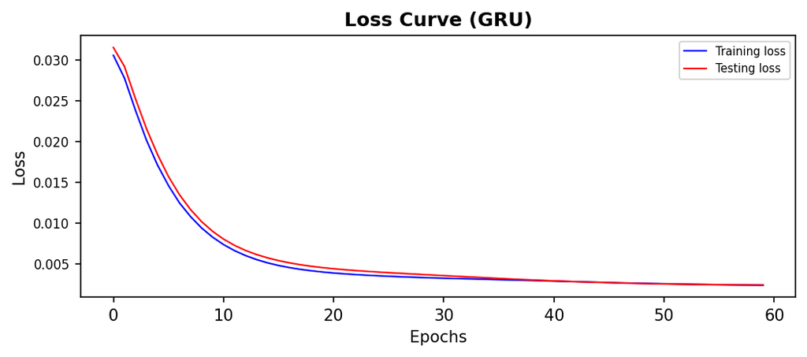

```python
def smooth_curve(points, factor=0.8): #this function will make our plots more smooth
	smoothed_points = []
	for point in points:
		if smoothed_points:
			previous = smoothed_points[-1]
			smoothed_points.append(previous*factor+point*(1-factor))
		else:
			smoothed_points.append(point)
	return smoothed_points


# plotting the training and validation loss
plt.figure(figsize=(8,3),dpi=150)
plt.plot(smooth_curve(training_losses), label='Training loss',color='blue',linewidth=1)
plt.plot(smooth_curve(testing_losses), label='Testing loss',color='red',linewidth=1)
plt.title('Loss Curve (GRU)',fontweight='bold')
plt.xlabel('Epochs', fontsize=10)
plt.ylabel('Loss', fontsize=10)
plt.yticks(size=8)
plt.legend(prop={'size': 7})
plt.show()
```

Plotting predicted values against actual values

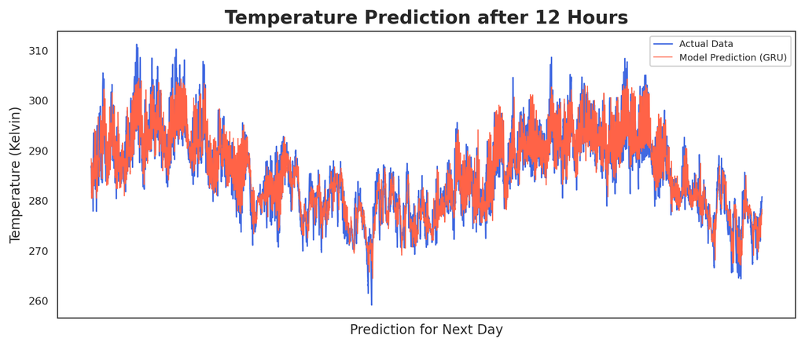

```python
plt.figure(figsize = (10,4), dpi=200)
sb.set_style("white")

sb.lineplot(x = original.index, y = original["+12 hour"], label="Actual Data", color='royalblue',linewidth=1)
sb.lineplot(x = predict.index, y = predict["+12 hour"], label="Model Prediction (GRU)", color='tomato',linewidth=0.7)
plt.title('Temperature Prediction after 12 Hours', size = 14, fontweight='bold')
plt.xlabel("Prediction for Next Day", size = 10)
plt.ylabel("Temperature (Kelvin)", size = 10)
plt.xticks(ticks=[])
plt.yticks(size=8)
plt.legend(loc="upper right", prop={'size': 7})
plt.show()
```